# Corona Indicator KNN

James Powell, Eva Mustavic, and Megan Lin

### Part 1

#### Implementation

This data set involves people who are experiencing symptoms of COVID-19 such as fever, tiredness, dry-couch, sore-throat, etc., as well as physical characteristics such as sex and age. We want to apply to KNN to this dataset to determine if we can create a model that predicts whether the patient will have covid or not.

Data Source: https://github.com/nshomron/covidpred/tree/master/data

#### Cleaning

The dataset was mostly clean, but was recoded where appropriate. Furthermore, our dataset was too large so a subset was created to accommodate for the RAM size RStudio allocated to projects.

```
## the negative to positive covid result ratio is shown by:  48979 1021
```

#### Metrics

##### Accuracy

test_indicationContact is chosen as the most important variable to improve our predictions.

```
## CART
##
## 40001 samples
##     8 predictor
##     2 classes: '0', '1'
##
## No pre-processing
## Resampling: Bootstrapped (25 reps)
## Summary of sample sizes: 40001, 40001, 40001, 40001, 40001, 40001, ...
## Resampling results across tuning parameters:
##
##   cp          Accuracy   Kappa
##   0.00000000  0.9871196  0.6080399
##   0.00244798  0.9873291  0.6195929
##   0.38678091  0.9837316  0.3473416
##
## Accuracy was used to select the optimal model using the largest value.
## The final value used for the model was cp = 0.00244798.
```

```
## Accuracy:  0.9873291
```

```
## test_indicationContact with confirmed
##                              653.9973
```

##### Confusion Matrix

```
## Confusion Matrix and Statistics
##
##           Actual
## Prediction    0    1
##          0 9768   93
##          1   27  111
##
##                Accuracy : 0.988
##                  95% CI : (0.9857, 0.99)
##     No Information Rate : 0.9796
##     P-Value [Acc > NIR] : 8.997e-11
##
##                   Kappa : 0.6432
##
##  Mcnemar's Test P-Value : 2.963e-09
##
##             Sensitivity : 0.5441
##             Specificity : 0.9972
##          Pos Pred Value : 0.8043
##          Neg Pred Value : 0.9906
##              Prevalence : 0.0204
##          Detection Rate : 0.0111
##    Detection Prevalence : 0.0138
##       Balanced Accuracy : 0.7707
##
##        'Positive' Class : 1
##
```

```
## [1] 0.0120012
```

From the above we can see our True Positive Rate or sensitivity is at 54%, False Positive Rate (1-Specificity) is at 0.3%, we want this to be low. The accuracy is at 98.8%. And the error is at 1.2% Aside from sensitivity, these are all very good numbers indicating an accurate, low error, and low false-positive likely model.

##### ROCR

We plotted the linear regression of the true positive rate against the false positive rate and color coded it.

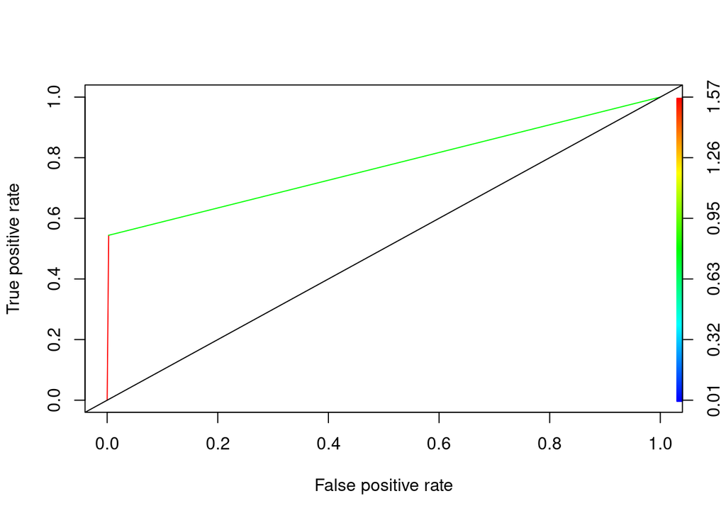

##### Other Metrics

```
## False Positive rate: .00276 or 27/9795
```

[output not shown]

```
## LogLoss:  4.592146
```

```
## F1 Score:  0.993895
```

The LogLoss ideally should be 0 so this could be further improved. This indicates some uncertainty in the data.

The F1 score is derived from the confusion matrix which then generates a precision and sensitivity score that is then weighted and combined to form the F1 score This number is pretty good since the ideal value is 1 indicating there are low false positive and low false negatives.

### Part 2

#### Confusion Matrix Thoughts

When you look at the confusion matrix shown above, it becomes obvious that a significant portion of the people with positive covid test results are being classified as negative. Almost half of the test set are being classified as such. Why is this? I think I want to trace this back to the weirdest thing that was shown in our KNN model, which is the variable importance.

#### Variable Importance

test_indicationContact with confirmed 653.9973

As you can see, if the person indicated that their reason for testing was that they had confirmed contact with a person that was infected with covid, then they are astronomically more likely to have contracted the disease yourself, and there were no other relevant variables. So, based on those things, I am willing to bet that the misidentified people who got classified in the false negative category were misidentified because by the by their lack of contact with a covid-positive person.

### Part 3

#### Threshold Adjustment

##### First Set

```r
adjust_thres(corona_eval_prob$`1`,0, test$corona_result)
```

```
## Confusion Matrix and Statistics
##
##           Actual
## Prediction    0    1
##          0    0    0
##          1 9795  204
##
##                Accuracy : 0.0204
##                  95% CI : (0.0177, 0.0234)
##     No Information Rate : 0.9796
##     P-Value [Acc > NIR] : 1
##
##                   Kappa : 0
##
##  Mcnemar's Test P-Value : <2e-16
##
##             Sensitivity : 1.00000
##             Specificity : 0.00000
##          Pos Pred Value : 0.02040
##          Neg Pred Value :     NaN
##               Precision : 0.02040
##                  Recall : 1.00000
##                      F1 : 0.03999
##              Prevalence : 0.02040
##          Detection Rate : 0.02040
##    Detection Prevalence : 1.00000
##       Balanced Accuracy : 0.50000
##
##        'Positive' Class : 1
##
```

```r
adjust_thres(corona_eval_prob$`1`,.01, test$corona_result)
```

```
## Confusion Matrix and Statistics
##
##           Actual
## Prediction    0    1
##          0 9768   93
##          1   27  111
##
##                Accuracy : 0.988
##                  95% CI : (0.9857, 0.99)
##     No Information Rate : 0.9796
##     P-Value [Acc > NIR] : 8.997e-11
##
##                   Kappa : 0.6432
##
##  Mcnemar's Test P-Value : 2.963e-09
##
##             Sensitivity : 0.5441
##             Specificity : 0.9972
##          Pos Pred Value : 0.8043
##          Neg Pred Value : 0.9906
##               Precision : 0.8043
##                  Recall : 0.5441
##                      F1 : 0.6491
##              Prevalence : 0.0204
##          Detection Rate : 0.0111
##    Detection Prevalence : 0.0138
##       Balanced Accuracy : 0.7707
##
##        'Positive' Class : 1
##
```

##### Second Set

These are all the same too

```r
adjust_thres(corona_eval_prob$`1`,.02, test$corona_result)
```

```
## Confusion Matrix and Statistics
##
##           Actual
## Prediction    0    1
##          0 9768   93
##          1   27  111
##
##                Accuracy : 0.988
##                  95% CI : (0.9857, 0.99)
##     No Information Rate : 0.9796
##     P-Value [Acc > NIR] : 8.997e-11
##
##                   Kappa : 0.6432
##
##  Mcnemar's Test P-Value : 2.963e-09
##
##             Sensitivity : 0.5441
##             Specificity : 0.9972
##          Pos Pred Value : 0.8043
##          Neg Pred Value : 0.9906
##               Precision : 0.8043
##                  Recall : 0.5441
##                      F1 : 0.6491
##              Prevalence : 0.0204
##          Detection Rate : 0.0111
##    Detection Prevalence : 0.0138
##       Balanced Accuracy : 0.7707
##
##        'Positive' Class : 1
##
```

```r
adjust_thres(corona_eval_prob$`1`,.10, test$corona_result)
```

```
## Confusion Matrix and Statistics
##
##           Actual
## Prediction    0    1
##          0 9768   93
##          1   27  111
##
##                Accuracy : 0.988
##                  95% CI : (0.9857, 0.99)
##     No Information Rate : 0.9796
##     P-Value [Acc > NIR] : 8.997e-11
##
##                   Kappa : 0.6432
##
##  Mcnemar's Test P-Value : 2.963e-09
##
##             Sensitivity : 0.5441
##             Specificity : 0.9972
##          Pos Pred Value : 0.8043
##          Neg Pred Value : 0.9906
##               Precision : 0.8043
##                  Recall : 0.5441
##                      F1 : 0.6491
##              Prevalence : 0.0204
##          Detection Rate : 0.0111
##    Detection Prevalence : 0.0138
##       Balanced Accuracy : 0.7707
##
##        'Positive' Class : 1
##
```

```r
adjust_thres(corona_eval_prob$`1`,.50, test$corona_result)
```

```
## Confusion Matrix and Statistics
##
##           Actual
## Prediction    0    1
##          0 9768   93
##          1   27  111
##
##                Accuracy : 0.988
##                  95% CI : (0.9857, 0.99)
##     No Information Rate : 0.9796
##     P-Value [Acc > NIR] : 8.997e-11
##
##                   Kappa : 0.6432
##
##  Mcnemar's Test P-Value : 2.963e-09
##
##             Sensitivity : 0.5441
##             Specificity : 0.9972
##          Pos Pred Value : 0.8043
##          Neg Pred Value : 0.9906
##               Precision : 0.8043
##                  Recall : 0.5441
##                      F1 : 0.6491
##              Prevalence : 0.0204
##          Detection Rate : 0.0111
##    Detection Prevalence : 0.0138
##       Balanced Accuracy : 0.7707
##
##        'Positive' Class : 1
##
```

```r
adjust_thres(corona_eval_prob$`1`,.75, test$corona_result)
```

```
## Confusion Matrix and Statistics
##
##           Actual
## Prediction    0    1
##          0 9768   93
##          1   27  111
##
##                Accuracy : 0.988
##                  95% CI : (0.9857, 0.99)
##     No Information Rate : 0.9796
##     P-Value [Acc > NIR] : 8.997e-11
##
##                   Kappa : 0.6432
##
##  Mcnemar's Test P-Value : 2.963e-09
##
##             Sensitivity : 0.5441
##             Specificity : 0.9972
##          Pos Pred Value : 0.8043
##          Neg Pred Value : 0.9906
##               Precision : 0.8043
##                  Recall : 0.5441
##                      F1 : 0.6491
##              Prevalence : 0.0204
##          Detection Rate : 0.0111
##    Detection Prevalence : 0.0138
##       Balanced Accuracy : 0.7707
##
##        'Positive' Class : 1
##
```

##### Third Set

These two are also the same

```r
adjust_thres(corona_eval_prob$`1`,.8, test$corona_result)
```

```
## Confusion Matrix and Statistics
##
##           Actual
## Prediction    0    1
##          0 9795  204
##          1    0    0
##
##                Accuracy : 0.9796
##                  95% CI : (0.9766, 0.9823)
##     No Information Rate : 0.9796
##     P-Value [Acc > NIR] : 0.5186
##
##                   Kappa : 0
##
##  Mcnemar's Test P-Value : <2e-16
##
##             Sensitivity : 0.0000
##             Specificity : 1.0000
##          Pos Pred Value :    NaN
##          Neg Pred Value : 0.9796
##               Precision :     NA
##                  Recall : 0.0000
##                      F1 :     NA
##              Prevalence : 0.0204
##          Detection Rate : 0.0000
##    Detection Prevalence : 0.0000
##       Balanced Accuracy : 0.5000
##
##        'Positive' Class : 1
##
```

```r
adjust_thres(corona_eval_prob$`1`,1, test$corona_result)
```

```
## Confusion Matrix and Statistics
##
##           Actual
## Prediction    0    1
##          0 9795  204
##          1    0    0
##
##                Accuracy : 0.9796
##                  95% CI : (0.9766, 0.9823)
##     No Information Rate : 0.9796
##     P-Value [Acc > NIR] : 0.5186
##
##                   Kappa : 0
##
##  Mcnemar's Test P-Value : <2e-16
##
##             Sensitivity : 0.0000
##             Specificity : 1.0000
##          Pos Pred Value :    NaN
##          Neg Pred Value : 0.9796
##               Precision :     NA
##                  Recall : 0.0000
##                      F1 :     NA
##              Prevalence : 0.0204
##          Detection Rate : 0.0000
##    Detection Prevalence : 0.0000
##       Balanced Accuracy : 0.5000
##
##        'Positive' Class : 1
##
```

##### Deductions

There are only 3 different possibilities as to the contents of the confusion matrices: all FALSE (not accurate), all TRUE (not accurate), and the one stationed in the middle of those two (we went over the metrics for this above). Because I was confused, I looked directly at the corona_eval_prob to see what the problem was. When I did this, I realized that this “optimal” KNN algorithm that was created off of all of Corona_Data’s training data, was simply using the “test_indication” variable to determine whether they would get covid. I mean it did work, it was more accurate than just guessing,however, while the FPR was amazing, the TPR was just okay. This is similar to the example we did in class about where the funfetti variable had too much emphasis.